```python
import MSA_entropy_plot as ali

input_file = "ENSG00000107643/thoraxe_2/non_kept_sequences.fasta"
msa1_path = "ENSG00000107643/thoraxe_2/can.fasta"
msa2_path = "ENSG00000107643/thoraxe_2/alt.fasta"
output_dir = "ENSG00000107643/thoraxe_2/aligned_sequences"
```

# Pipeline

## 1. **Définition des Fonctions Utilitaires**

- **`calculate_presence_matrix`** : Calcule une matrice de présence qui représente le pourcentage d'apparition de chaque acide aminé à chaque position de l'alignement. Des poids peuvent être appliqués aux positions jugées importantes.
- **`calculate_sequence_score`** : Évalue un score pour une séquence donnée en fonction de sa conformité à la matrice de présence, ce qui permet de juger son alignement potentiel.
- **`align_sequences_to_msas`** : Intègre de nouvelles séquences dans l'un des deux MSA basés sur les scores dérivés de leur conformité à la matrice de présence, ou les classe comme indécises.
- **`calculate_kl_divergence`** et **`calculate_aa_distribution`** : Utilisés pour mesurer la divergence de Kullback-Leibler entre les distributions d'acides aminés des colonnes de deux MSA, important pour identifier des positions où les profils d'acides aminés diffèrent de manière significative.
- **`find_important_positions_with_weights`** : Détermine les positions importantes en fonction des divergences de Kullback-Leibler entre deux MSA, et assigne des poids à ces positions.

## 2. **Exécution Principale**

- Charge les fichiers des deux MSA à partir de chemins spécifiés.
- Identifie les positions importantes en utilisant les divergences de Kullback-Leibler.
- Calcule la matrice de présence pour le premier MSA en tenant compte des positions importantes.

# Divergence de Kullback-Leibler explication des poids

La divergence de Kullback-Leibler (KL) est une mesure statistique utilisée pour quantifier la différence entre deux distributions de probabilités. Elle est souvent utilisée en théorie de l'information, en statistique et en apprentissage automatique pour mesurer combien une distribution ( P ) s'écarte d'une distribution de référence ( Q ). Voici une explication détaillée de la divergence KL et de son utilisation des poids dans le contexte du traitement de séquences biologiques.

La divergence KL de la distribution ( P ) par rapport à la distribution ( Q ) (notée ( D_{KL}(P \parallel Q) )) est définie comme suit :

[ D_{KL}(P \parallel Q) = \sum_{i} P(i) \log \left(\frac{P(i)}{Q(i)}\right) ]

où ( P ) et ( Q ) sont des distributions de probabilités, et la somme est prise sur tous les événements ( i ) possibles dans ces distributions. Voici quelques points clés à propos de la divergence KL :

- **Mesure non symétrique** : ( D_{KL}(P \parallel Q) ) n'est pas égale à ( D_{KL}(Q \parallel P) ). Cela signifie que le "coût" de passer de ( P ) à ( Q ) est différent de celui de passer de ( Q ) à ( P ).
- **Interprétation** : Si ( P ) est identique à ( Q ), la divergence KL est zéro car il n'y a aucune différence entre les deux distributions. Des valeurs plus élevées indiquent des différences plus grandes entre ( P ) et ( Q ).
- **Domaine de valeurs** : La divergence KL est toujours non-négative (( D_{KL}(P \parallel Q) \geq 0 )), avec égalité seulement quand ( P ) est identique à ( Q ).

## Poids associés à la divergence KL

1. **Calcul des distributions** : Pour chaque position dans l'alignement, calculez la distribution des acides aminés pour chaque ensemble de séquences (par exemple, deux MSA différents).
2. **Divergence KL pour chaque position** : Calculez la divergence KL entre les deux distributions à chaque position. Cela donne une mesure de combien les distributions diffèrent à cette position précise.
3. **Attribution de poids** : Utilisez la divergence KL comme un "poids" pour cette position. Des valeurs plus élevées indiquent des différences plus marquées et, potentiellement, une importance biologique plus grande. Ces poids peuvent influencer des analyses ultérieures, comme le calcul de matrices de présence ou l'ajout de séquences à un MSA.
4. **Normalisation** : Les poids peuvent être normalisés de manière à ce que leur somme totale soit constante, permettant une comparaison uniforme à travers l'alignement.

# Signature of exons

```
There are 10 sequences, all of length 24
```

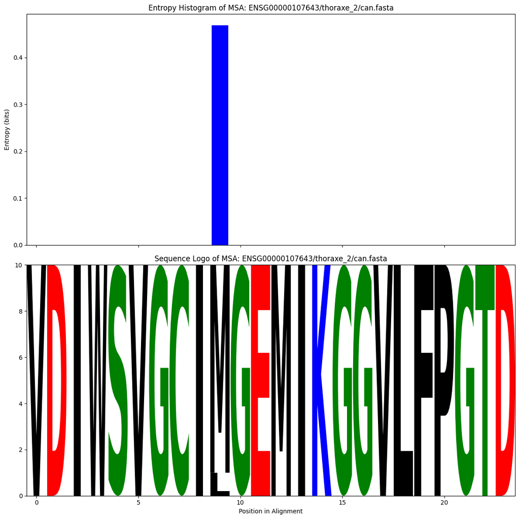

```python
# Charger les MSA depuis les fichiers
ali.plot_msa_analysis(msa1_path)
```